The Lads Travel Co.

Real Spots · Honest Takes · Est. 2026

The Lads Travel Co.

# Real Places. Real Knowledge. *Built to Actually Use.*

Every destination below is backed by firsthand experience, a validated spot database, and a designed trip framework you can open on your phone and follow. Not a blog post. Not a Pinterest board. Something you can actually travel with.

Personally Validated Destinations

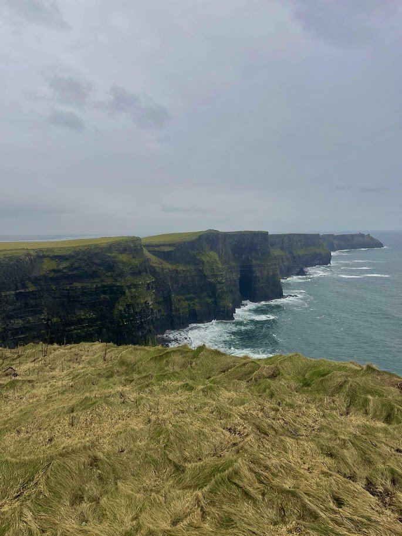

Dublin + Galway

DUBLIN → KILKENNY → GALWAY → CLIFFS OF MOHER

Both Lads — Personally Validated

35+

Pubs Documented

3

Timing Versions

45+

Validated Spots

3

Day Trips Included

Christmas markets, St. Patrick’s Day, or summer — three completely different trips from the same two cities. Every pub rated, every attraction mapped, every day trip personally taken. The framework includes full cost breakdowns, accommodation strategy by group size, and our Google Maps lists so you can navigate on the ground.

Day Trips That Make This Trip

Cliffs of Moher + Burren

Full day from Galway. Brady rated 9/10.

[Book →](https://www.viator.com/tours/Galway/Cliffs-of-Moher-and-Burren-Day-Trip-Including-Dunguaire-Castle-Aillwee-Cave-and-Doolin-from-Galway/d5156-8625P1)

Wicklow Mountains + Glendalough + Kilkenny

Full day from Dublin. Medieval castle, monastic ruins, mountains.

[Book →](https://gyg.me/V0UrxNUe)

Open Full Framework → [Pubs & Food](https://maps.app.goo.gl/NrZtg6tUR1Rjk8oS8) [Dublin Attractions](https://maps.app.goo.gl/9YLakDkjrE6jj7cQA) [Galway](https://maps.app.goo.gl/deRD11SQis6ZUsKL8)

[figure not shown]

Rome + Italy

ROME → VATICAN → TRASTEVERE → POMPEII → AMALFI COAST

Both Lads — Personally Validated

11/10

Pompeii Rating

43

Validated Spots

2025

Jubilee Year

2

Day Trips Included

Five days during the Jubilee Year. €1 beers at Bar San Calisto, cacio e pepe at Tonnarello, the Vatican with holy doors open, and the once-in-a-generation experience of witnessing the passing of Pope Francis. The framework includes Trastevere nightlife routing, restaurant tiers, and a full Pompeii day trip plan.

Day Trips That Make This Trip

Pompeii + Amalfi Coast + Sorrento

Full day from Rome. Pompeii is non-negotiable — 11/10.

[Book →](https://gyg.me/c6cN0bz2)

Open Full Framework → [Food & Drink](https://maps.app.goo.gl/kmFjNeA6k8BHuHWT8) [Attractions](https://maps.app.goo.gl/RAS5mqRhc6BYTa5D6)

[figure not shown]

Barcelona + Madrid

BARCELONA → MONTSERRAT → GIRONA → SITGES → MADRID → TOLEDO

Both Lads — Personally Validated

100+

Validated Spots

3

Group Size Versions

2

Study Abroads

3

Day Trips Included

Day Trips That Make This Trip

Montserrat + Girona + Sitges

Full day from Barcelona. Mountain monastery, medieval town, coastal village.

[Book →](https://www.viator.com/tours/Barcelona/From-Barcelona-Montserrat-Girona-and-Sitges-Full-Day-Tour/d562-6874P164)

Open Full Framework → [Food](https://maps.app.goo.gl/bZp95gDP9VwBe6Kd7) [Bars](https://maps.app.goo.gl/2LZGLZQEuT53NK3Z8) [Attractions](https://maps.app.goo.gl/63o5dgY5Fr8SJUZk6)

[figure not shown]

Australia + New Zealand

SYDNEY → BONDI → BLUE MOUNTAINS → TASMANIA → SOUTH ISLAND NZ

Brady — Personally Validated

6

Weeks Living There

79+

Validated Spots

4

Days Tasmania

123

Total Spots in DB

The deepest single-city knowledge base in the portfolio. Surf camps, rock pools, Vivid Sydney light shows, and the best bánh mì in Marrickville. Six weeks of actually living there — not visiting. Extended with four days in Tasmania and research-based coverage of New Zealand’s South Island.

Open Full Framework →

Also Personally Validated

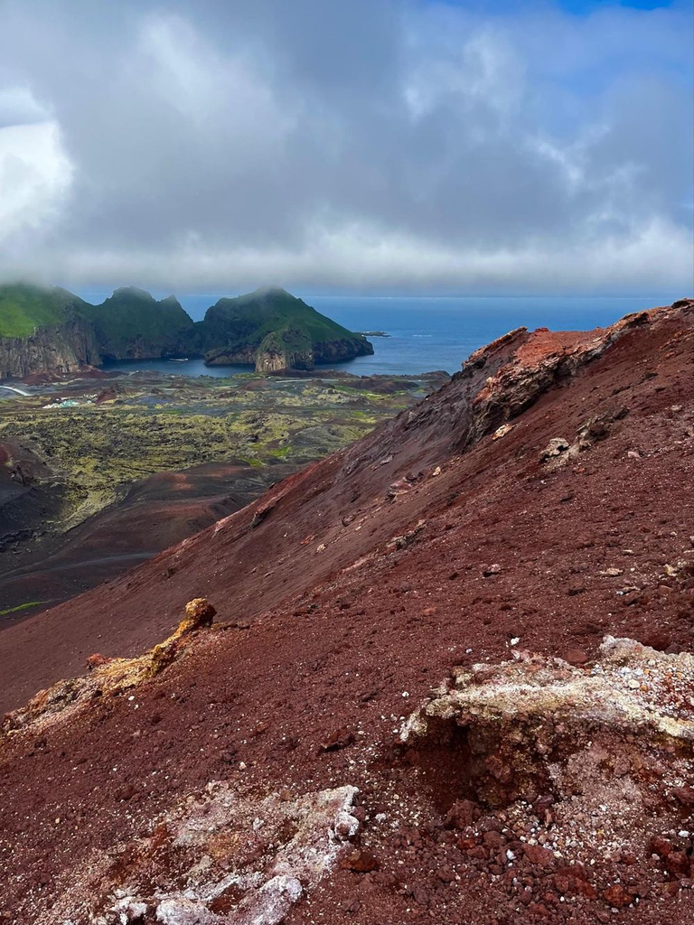

Dawson — Validated

Iceland

REYKJAVÍK → GOLDEN CIRCLE → RING ROAD → WESTMAN ISLANDS

Full Ring Road. Four versions: summer or winter, short or long. Northern Lights, Midnight Sun, volcanic landscapes, and the most dramatic driving route in Europe.

Open Framework →

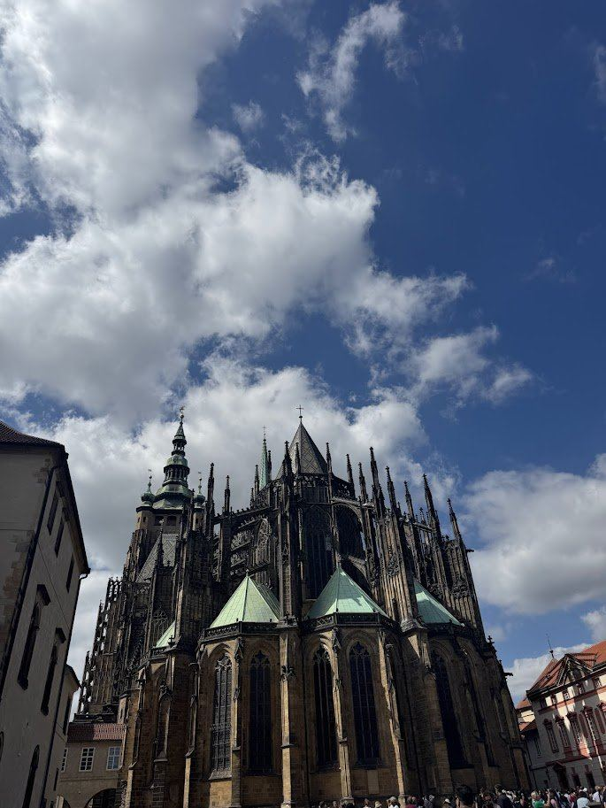

Brady — Validated

Prague + Vienna + Dresden

VIENNA → PRAGUE → PILSEN → DRESDEN

Pilsner Urquell brewery. Schönbrunn Palace. St. Vitus Cathedral. Best value city in Europe meets Habsburg grandeur, with a Pilsen brewery day trip and Dresden as a day trip from Prague.

Framework → [Vienna](https://maps.app.goo.gl/R4TC9toa9oP5qJed8) [Prague](https://maps.app.goo.gl/e3pGDSj6PCcPEy8j7) [Dresden](https://maps.app.goo.gl/FYEJQFkTJVyqZr1x7)

The Lads Travel Co.

© 2026

The System

# How This *Actually Works*

Most travel advice comes from people who googled a place. Ours comes from people who lived it — then built a research system to handle everything else.

Five Steps

01

Fill out the intake

90 seconds. Where, who, when — or “no idea yet.”

02

15-minute call with Brady

Flights, accommodation, experiences, budget — all of it.

03

Research runs

Six AI agents across flights, neighborhoods, experiences, and savings.

04

Framework delivered

Designed HTML document. Cost breakdowns, validated spots, money intelligence. Works on your phone.

05

Follow-up included

Questions after delivery are part of the deal.

The Research Engine

Air Intelligence finds the flights. Neighborhood & Stay finds where to sleep. Experience Architect builds the days. Ways to Save finds where the money goes. The result is a framework specific enough to act on and honest enough to trust — for any destination on earth, whether we’ve been there or not.

The Lads Bucket List

Trips We’re *Building Next*

These frameworks were built entirely by our research system — proof that we can plan any trip, anywhere, for anyone. Some we’re about to do ourselves. All are available now.

Munich Oktoberfest

Framework Ready

CHICAGO → REYKJAVÍK → MUNICH → SALZBURG → NEUSCHWANSTEIN

Augustiner-Bräu tent strategy. Glockenbachviertel neighborhood base. September 2026 arrival window. Complete cost model for groups of 4–10. Brady planning to attend.

4–10 people

5–8 days

Sept 19–Oct 4 window

Open Framework →

Poland August

Framework Ready

CHICAGO → KRAKOW → WIELICZKA → WARSAW → GDAŃSK

Krakow as the anchor. Warsaw and Gdańsk as extensions. Three duration versions. LOT Airlines non-stop from ORD. Brady planning to attend August 2026.

4–8 people

6–10 days

Aug 2026 target

Open Framework →

Thailand NYE

Framework Ready

BANGKOK → KOH PHANGAN → KRABI → RAILAY BEACH

December 26 to January 11. Cathay Pacific via Hong Kong. Full moon party timing. Island-hopping logistics and beach-to-city transitions solved.

4–8 people

10–16 days

Dec–Jan window

Open Framework →

Tour du Mont Blanc

Building

CHAMONIX → HUT-TO-HUT → COURMAYEUR → SWITZERLAND → FRANCE

The classic Alpine hut-to-hut trek across three countries. Adventure-tier bucket list alongside Machu Picchu. Framework in development.

2–6 people

7–11 days

Jul–Sep window

Pilsenfest + Prague

Building

PRAGUE → PILSEN → PILSNER FEST → CZECH COUNTRYSIDE

Research meets firsthand knowledge. Brady’s Pilsen brewery experience combined with festival-specific logistics. The proof that personal validation + the research engine creates something neither can alone.

2–8 people

4–7 days

Oct annual

Camp Nou Reopening

Building

BARCELONA → CAMP NOU → MATCH DAY → MONTSERRAT

The newly renovated Camp Nou combined with our deepest city — 100+ validated Barcelona spots. Match-day logistics, ticket strategy, and the full Barcelona framework wrapped around a once-in-a-generation stadium reopening.

2–8 people

5–8 days

2025–26 reopening

Ryder Cup 2027 Ireland

Building

DUBLIN → ADARE MANOR → LIMERICK → KILLARNEY → GALWAY

September 2027 at Adare Manor. Golf trip of a lifetime wrapped inside the Ireland we already know — 39 Dublin spots, 15 Galway spots, and Dawson’s full pub validation. Research PDF complete. Framework in development.

2–8 people

7–10 days

Sep 2027 event

More Building

The bucket list grows. If you have a trip in mind — anywhere in the world, any group size, any budget — the system can build it. That’s the point.

The Database

650+ spots. *20+ cities.*

Personally visited, rated, and filed into Google Maps lists you can use on the ground.

Sydney

123

spots

Barcelona

115

spots

Rome

43

spots

Dublin

39

spots

Prague

38

spots

Vienna

37

spots

Costa Rica

28

spots

Tasmania

27

spots

Vancouver

22

spots

Galway

15

100% rated

Travel Windows

Four windows. Each one backed by fare data, crowd analysis, and weather patterns. We build every framework around these because timing is the single biggest lever you have on cost, crowds, and experience quality. Click to open.

Late November / Early December

The underrated one. Cheap flights, thin crowds, Christmas markets.

▼

25-40%

Below Peak Fares

Low

Crowd Level

35-50°F

Avg Europe Temp

Why This Window Works

Transatlantic fares crater after Thanksgiving through mid-December. Airlines are desperate to fill seats during the gap between holiday travel waves. Round-trip flights from the Midwest to major European hubs consistently drop into the $400-550 range — compared to $700-900 during summer peak. The sweet spot is departing the Tuesday or Wednesday after Thanksgiving and returning before December 18th, when holiday pricing kicks in hard.

Proof from Our Frameworks

- Our Dublin framework includes a Christmas market version of the itinerary — Dublin’s Christmas Funderland and Galway’s market district are world-class in early December, and you’re paying a fraction of what July visitors pay
- Prague and Vienna are literally built for this window — Christmas markets open mid-November, and both cities hit peak atmosphere when temperatures drop. Our database has 75 combined spots across both cities
- Rome in late November means no lines at the Vatican, $450 flights from ORD, and restaurant reservations that would require three weeks’ notice in June

What People Get Wrong

They assume cold weather ruins Europe. It doesn’t. Most European cities are built for indoor culture — pubs, restaurants, museums, markets. You’re not going to sit on a beach in Dublin in July either. The weather objection is a cope for people who haven’t thought through what they’re actually doing on the trip.

Best For

Culture-heavy travelers. Couples. Small groups who want city trips without fighting crowds. Anyone with flexible PTO who can skip the holiday travel rush.

Skip If

You want beach or outdoor adventure. You can’t handle 4pm sunsets. You’re bringing a large group that needs warm-weather energy to stay engaged.

The Lads Take

This is the window nobody talks about because travel influencers don’t post content from 40-degree Dublin. Their loss. You’re saving $300+ per person on flights and walking into the best pubs and restaurants in Europe without a reservation.

Late April / Early May

The shoulder season sweet spot. Post-Easter, pre-peak across Europe.

▼

15-30%

Below Peak Fares

Medium

Crowd Level

55-70°F

Avg Europe Temp

Why This Window Works

The two weeks after Easter through mid-May hit a pricing gap airlines haven’t figured out how to close. Summer pricing usually kicks in around May 15th for most European routes, but the weather is already excellent by late April. You get 14-16 hours of daylight, outdoor dining is open, and accommodations are 20-35% cheaper than June. The key is booking after Easter Sunday passes — the holiday premium evaporates within days.

Proof from Our Frameworks

- Our Spain framework targets this window specifically — Barcelona in late April averages 65°F, tapas bars have outdoor seating running, and Montserrat day trips aren’t packed with summer tour buses. We have 115 spots in Barcelona alone; you can actually enjoy them without queueing
- Rome and the Amalfi Coast open up perfectly in this window. Our Italy framework’s Pompeii + Amalfi day trip is genuinely pleasant at 60°F vs. genuinely miserable at 95°F in August
- Iceland’s shoulder season starts in late April — Dawson’s Ring Road framework notes roads reopening and waterfalls at peak flow from snowmelt, with tourist numbers at a quarter of July’s volume

What People Get Wrong

People wait for “summer weather” and end up paying $300 more per flight, booking accommodations 4 months out, and standing in 90-minute lines at the Sagrada Familia. Late April in Southern Europe is warmer than most people’s home cities. You don’t need July to eat dinner outside in Barcelona.

Best For

Groups of 3-6 who want the full experience — outdoor dining, walking cities, day trips — without peak pricing or peak crowds. Ideal for Southern and Western Europe.

Skip If

You need guaranteed 80°F+ beach weather. You’re targeting Scandinavia (still cold). You’re locked into a specific Easter travel week — that’s still peak pricing.

The Lads Take

If you can swing late April, you’re getting 90% of the summer experience at 70% of the cost. This is the window we recommend most often for first-time Europe travelers who think they need to go in June.

August

Beach destinations only. Everything else is a trap.

▼

Peak

Fare Pricing

Maximum

Crowd Level

85-100°F

Southern Europe

Why August is a Trap (For Most Destinations)

August is when every European takes their annual holiday. Every. Single. One. The entire continent is on the move. Flights from the US hit annual maximums — $800-1,100 round-trip to most European hubs from ORD/DTW. Accommodations in popular cities can run 40-60% above shoulder season rates. Rome, Barcelona, and Paris are hitting 95-100°F with no relief. You’re paying the most money to have the worst version of the experience.

The Exception: Beach + Tropical

- Thailand in August is monsoon season — skip it. But Costa Rica’s Pacific coast (Jacó, our top domestic pick) has its green season with afternoon showers, lower prices, and warm water. Our database has 28 validated spots there
- Australia is in winter during August — Sydney averages 62°F, so this is a culture/food window, not a beach window. Our framework has 123 spots in Sydney that work year-round
- If you must go in August, go where heat is the point: Greek islands, Croatia coast, or the beach destinations where you’re in the water all day anyway

What People Get Wrong

They book August because it’s when they have time off, then build the destination around the dates. That’s backwards. August in Rome means 45-minute waits at the Colosseum in 97°F heat. August in Barcelona means La Rambla is shoulder-to-shoulder tourists with every restaurant running a prix fixe tourist menu. If August is your only option, pick a beach destination and own it. Don’t try to force a city trip.

Best For

Beach-only trips. Groups locked into August PTO who accept the premium and choose destinations built for heat. Costa Rica, Greek islands, Croatian coast.

Skip If

You want European city trips. You’re budget-conscious. You want to actually enjoy museums, walking tours, or outdoor dining without sweating through your shirt by 10am.

The Lads Take

We actively steer clients away from August for European cities. Not because we’re being difficult — because we’ve seen the difference. The same trip in September is cheaper, cooler, and less crowded. If your group can only do August, we’ll build you something great, but it’s going to be a beach trip.

Our #1 Recommendation

Late August / September Post-Labor Day ★

The overall winner. Crowds vanish, prices follow, weather stays excellent.

▼

20-35%

Below Peak Fares

Low-Med

Crowd Level

65-80°F

Avg Europe Temp

Why This Window Wins

The week after Labor Day is the single best inflection point in the travel calendar. Here’s what happens simultaneously: American families go back to school, European holidays end, airlines drop fares to fill suddenly-empty transatlantic routes, and the weather across Southern and Central Europe is still in the 70s. It’s the rare convergence where every variable — price, crowds, weather, availability — moves in your favor at the same time.

Transatlantic fares from DTW and ORD to major European hubs typically drop $200-350 from their August peaks within the first week of September. Accommodation in cities like Barcelona, Rome, and Prague can be 25-40% cheaper than July-August rates. And critically, availability opens up — restaurants, tours, and experiences that require weeks of advance booking in summer become walk-in accessible.

Proof from Our Frameworks

The Data Behind the Recommendation

- **Flights:** Average round-trip ORD→European hub drops from ~$850 (peak July/Aug) to ~$550-650 by mid-September. DTW shows similar patterns with slightly higher baselines. Booking 6-8 weeks out from a September departure consistently produces the best fare-to-quality ratio we’ve tracked
- **Accommodation:** Airbnb and hotel rates in major European cities drop 25-40% after Labor Day. A 4-person apartment in Barcelona’s Eixample that runs $280/night in August drops to $170-190 by September 10th
- **Crowds:** Major attractions see 30-50% visitor reduction in the first two weeks of September vs. August. The Vatican Museums, Park Güell, and the Colosseum all shift from “book 3 weeks out” to “book 3 days out”
- **Weather:** Mediterranean Europe (Spain, Italy, Greece) averages 75-82°F through September. Central Europe (Prague, Vienna, Munich) sits at 65-72°F. Ireland and the UK are at 58-64°F. All of these are more comfortable for walking cities than the 90°F+ of August

What People Get Wrong

They think September means fall, and fall means cold. In Southern Europe, September is still summer — just without the crowds. Barcelona doesn’t dip below 70°F until late October. Rome’s outdoor dining runs through November. Even Munich during Oktoberfest opening weekend is averaging mid-60s, which is perfect for a beer tent. The other mistake: people assume “post-Labor Day” means limited PTO flexibility. It’s actually easier — you’re not competing with every other person in your office for the same summer weeks.

Best For

Everyone. Seriously. Groups of any size, any budget tier, any trip style. This is our default recommendation for European city trips, and it’s the window we plan most of our own trips around. Especially strong for first-timers who want the best possible version of their first Europe trip.

Skip If

You specifically need a holiday break (Thanksgiving, Christmas, spring break) or you’re targeting Southern Hemisphere destinations where September is early spring and still building toward peak season.

The Lads Take

Flight Intelligence

How We Find the Deals

Timing a flight isn’t luck. It’s understanding how airline revenue management actually works and building a system around it. Here’s everything we use, why it works, and what most people miss. This is the same playbook behind every framework we build.

Understanding the Machine

1

How Airline Pricing Actually Works

Foundation

**What this means for you:** Price drops aren’t random sales. They’re the system reopening lower buckets because demand is tracking below projections. When you see a fare drop on a Tuesday afternoon six weeks before departure, that’s the algorithm saying “this flight is undersold relative to where it should be.” Understanding this is the difference between booking reactively and booking with intent.

**The practical move:** Never book on the first search. Track a route for 3-5 days to establish a baseline. If the fare jumps $40+ overnight, a lower bucket just closed — it might reopen, or it might not. If it drops $50+, a bucket just opened — that’s your window. Most travelers see one price and either book immediately or wait indefinitely. Both are wrong.

2

The Booking Window That Actually Matters

Timing

The old “book 54 days out” advice is dead. Post-pandemic, airlines rebuilt their revenue management models with new demand data, and the optimal booking windows shifted. For transatlantic economy from the Midwest, the data now shows two sweet spots:

6-10 Weeks

Primary Sweet Spot

2-3 Weeks

Last-Minute Drops

The 6-10 week window is when airlines have enough booking data to see whether a flight is tracking above or below their demand curve, but they’re still far enough out that unsold inventory triggers bucket reopening. The 2-3 week window is riskier — you might catch a desperate fare drop on an undersold flight, or you might find that every lower bucket is closed and you’re paying top dollar.

**What changed post-pandemic:** Airlines learned that leisure travelers book later than they used to, so they’ve pushed discount bucket release dates later to match. The old model punished late bookers aggressively; the new model keeps more low-bucket inventory available into that 6-8 week range. But the flip side is that very early bookings (4-6 months out) no longer guarantee the best price — airlines now price early availability higher because they know people booking that far out are less price-sensitive.

**For our frameworks:** We built Poland’s late August timing around a July booking window — 6-8 weeks out from departure, right in the sweet spot. Munich Oktoberfest (September 24-26) means booking in early August. If you’re reading this in April and planning a September trip, you’re actually ahead of the optimal booking window, which means you can set up tracking now and buy when the bucket opens.

The Tools We Actually Use

3

Google Flights + Fare Alerts

Primary Tool

Google Flights is the foundation. Not Kayak, not Skyscanner, not Hopper. Google Flights. The reason is data freshness — Google pulls directly from airline GDS (Global Distribution System) feeds and updates multiple times per hour. Third-party aggregators cache results, which means the fare you see on Kayak might be 2-6 hours stale. On a competitive transatlantic route, that’s the difference between a $480 fare and a $620 fare.

**The features most people ignore:**

- **Flexible date grid:** The calendar view showing +/- 3 days on either end. On ORD→Dublin routes, we’ve seen $200+ variance between a Tuesday and Thursday departure in the same week. The grid makes this visible in seconds
- **Price tracking:** Set a tracked price on your exact route and dates. Google will email you when the fare changes. But here’s what people miss: set tracking on 3-4 date variants, not just your ideal dates. The cheapest variant wins
- **“Explore” mode:** Enter your departure airport and leave the destination blank. Google shows you a map of the cheapest fares to every destination. We’ve used this to redirect clients from their planned destination to a cheaper one with a similar experience — Prague instead of Vienna when the fare delta was $280 per person
- **The “price guarantee” badge:** Google now flags routes where their ML model predicts the fare is at or near its lowest point. It’s not always right, but when it appears alongside your tracked price being in the bottom 20% of historical range, that’s a strong buy signal

4

Error Fares + Secret Deals

Advanced

Error fares are real. Airlines make pricing mistakes — currency conversion errors, missing fuel surcharges, mistyped fares filed in the ATPCO system. These show up as flights priced 40-70% below normal. Most last 2-12 hours before the airline catches it. Some get honored, some get cancelled. The DOT’s full-fare advertising rule means airlines are supposed to honor ticketed fares, but enforcement is inconsistent.

**Where to find them:**

- **Secret Flying:** Dedicated error fare aggregator. Their team monitors ATPCO filings and automated fare scrapers 24/7. Set up alerts for your departure airports (ORD and DTW specifically). We’ve seen ORD→Barcelona error fares at $280 round-trip that held
- **Skiplagged:** Not an error fare tool — it surfaces hidden-city ticketing opportunities. A flight from DTW→Munich might cost $750, but DTW→Prague with a connection in Munich might be $520. You get off in Munich and skip the Prague leg. The catch: no checked bags (they’ll go to Prague), you can’t do this on the return leg, and airlines will cancel your frequent flyer account if they catch a pattern. We use this selectively for outbound legs only
- **Google Flights + date flexibility:** Sometimes what looks like a “deal” on aggregator sites is just normal bucket pricing on an off-peak day. Check Google Flights first to baseline the route before assuming something is an error

**Our rule:** Book error fares on a refundable credit card. If the airline cancels the ticket, you get your money back. If they honor it, you just saved $400 per person. Risk-free optionality.

5

Flexible Date Searching — The Real Savings Lever

High Impact

This is the single most impactful thing a group can do, and almost nobody does it properly. Moving your departure by +/- 2 days on a transatlantic route regularly saves $150-300 per person. On a group of 6, that’s $900-1,800 — enough to fund an entire day trip or three nights of dinners.

$150-300

Per Person / +/- 2 Days

Tue & Wed

Cheapest Departure Days

**Why Tuesday/Wednesday departures win:** Business travelers fly Sunday night and Monday morning (outbound) and Thursday/Friday (return). Airlines price these days higher because demand from corporate accounts is inelastic — the company is paying, so the traveler doesn’t care about $200. Leisure travelers get punished for flying on business traveler days. A Tuesday evening departure to Europe means you land Wednesday morning, which functionally gives you the same trip as a Monday departure but at a midweek fare.

**Return day trick:** Flying back on a Monday or Tuesday instead of Sunday saves even more. Sunday returns from Europe to the US are peak-priced because everyone wants to be home for the work week. Monday returns are consistently 15-25% cheaper on the same routes. You lose one day of your weekend, but you gain it as a cheaper, less stressful travel day with shorter security lines and emptier planes.

Routing Strategies

6

Open-Jaw Routing vs. Round Trip

Architecture

A round trip forces you to return to where you started. An open-jaw lets you fly into one city and out of another — fly into Barcelona, train to Rome, fly home from Rome. Most people don’t know this is often the same price or cheaper than a round trip, because airlines price each leg independently based on that leg’s demand.

**When open-jaw saves money:** When one city has significantly cheaper inbound fares and another has cheaper outbound fares. ORD→Dublin is historically cheaper than ORD→London, but London→ORD can be cheaper than Dublin→ORD because of British Airways’ hub competition. An open-jaw (ORD→Dublin, London→ORD) might beat a Dublin round trip by $80-150.

**How we use it in frameworks:** Our Spain framework is built for open-jaw — fly into Barcelona, train to Madrid (2.5 hours, ~$40 on Renfe AVE), fly home from Madrid. This eliminates a backtrack, adds a second city, and often prices within $30 of a Barcelona round trip. Our Italy framework uses the same logic — into Rome, Pompeii/Amalfi day trip south, then potentially out of Naples or back from Rome depending on what the fares do.

7

Hub Arbitrage — ORD and DTW Route Tricks

Midwest-Specific

O’Hare and Detroit Metro are two of the best-positioned airports in the Midwest for transatlantic travel, and each has specific advantages most travelers don’t know about.

**ORD advantages:**

- United’s transatlantic hub. Nonstop service to 20+ European cities. When United runs a fare sale, ORD gets the deepest discounts because they’re protecting hub market share
- Icelandair flies ORD→Reykjavik (KEF) with one-stop connections to 25+ European destinations. Their pricing model undercuts the majors by 15-25% because they’re routing through a smaller hub with lower airport fees. Our Munich framework uses this — ORD→KEF→MUC can be $150+ cheaper than ORD→MUC nonstop on Lufthansa
- Norse Atlantic (when available) and PLAY offer budget transatlantic options through KEF/OSL that traditional search engines sometimes miss. Check these carriers directly

8

Group Booking Splits

Group Travel

This is one of the most important things we tell groups, and almost no one knows it. **Never book 6 seats on the same search.**

**The fix:** Search and book in pairs. Two tickets at a time. The first pair gets the lowest available bucket. The second pair gets the next-lowest. Even if the third pair pays more, your average fare across all six tickets is lower than booking all six together. We’ve seen this save $50-120 per person on transatlantic routes for groups of 4-6.

**The catch:** You might not all get seats together. For a group of lads on a 7-hour transatlantic flight, this usually doesn’t matter. You’re sleeping or watching movies. Save the $300-700 as a group and put it toward the trip.

Money Strategies Beyond Flights

9

Credit Card Signup Bonuses + Referral Cascades

Points Game

A single Chase Sapphire Preferred signup bonus (60,000-80,000 Ultimate Rewards points) is worth $750-1,000 in travel when transferred to airline partners. That’s enough for a round-trip to Europe in economy through United MileagePlus or a domestic flight on Southwest. The annual fee is $95, which means the net value of the signup bonus alone is $655-905.

**The referral cascade for groups:** Person 1 signs up, earns the bonus, then refers Person 2. Person 1 gets 15,000 referral points. Person 2 gets the full signup bonus. Person 2 refers Person 3. Repeat. For a group of 5, this generates the equivalent of one additional free round-trip flight in referral bonuses alone, on top of everyone’s individual signup bonuses.

**The cards that matter for travel in 2026:**

- **Chase Sapphire Preferred:** Best entry point. 60-80K bonus, 2x on travel/dining, transfer partners include United, Hyatt, Southwest. Hyatt transfers are the single best point-per-dollar value in the game
- **Capital One Venture X:** 75K bonus, $300 annual travel credit effectively makes the $395 fee a $95 fee. Transfer partners include Air Canada (Star Alliance access), Turkish Airlines (incredible sweet spots to Europe), and Air France/KLM
- **Amex Gold:** Not a travel card — it’s a dining card that feeds travel. 4x on restaurants and groceries means everyday spending builds a point balance that transfers to Delta, British Airways, or ANA at strong ratios

**Timing it:** Sign up 3-4 months before your trip. Hit the minimum spend organically (don’t manufacture spend). Transfer points to the airline partner with the best award availability for your route. Book the award flight. This works especially well for the one person in the group who’s organizing — put the Airbnb, group dinners, and activity deposits on the new card to hit minimum spend naturally.

10

Seasonal Sale Patterns

Calendar

Airlines run fare sales on predictable cycles. Knowing these cycles means you can plan when to be actively searching vs. when to set alerts and wait.

- **January 2-15 (“Travel Tuesday” period):** The single best sale window of the year. Airlines dump summer inventory at 20-40% discounts to generate early bookings for their Q2/Q3 revenue forecasts. This is when to book summer Europe trips. Almost every major carrier runs a transatlantic sale in this window
- **Black Friday / Cyber Monday week:** Real, but overhyped. The discounts are genuine (15-25% on select routes) but the route selection is narrow — airlines use this to move specific underperforming routes, not as a blanket sale. Worth checking, but don’t hold out for it if you’ve already found a good fare in October
- **Tuesday/Wednesday afternoon drops:** Airlines file new fares on Monday evenings. Competitors match on Tuesday. By Wednesday afternoon, the lowest matched fares are live across all carriers. This is why “book on Tuesday” became conventional wisdom — and it’s still true, but the window is tighter than it used to be. Set alerts rather than manually searching every Tuesday
- **48 hours after a competitor launches a route:** When a new carrier announces service on a route (e.g., Norse Atlantic adding ORD→Berlin), existing carriers on that route drop fares within 48 hours to protect market share. These competitive responses often produce the best fares of the year on that route, and they last 1-3 weeks

11

Fare Class Monitoring + Bucket Watching

Advanced

This is where casual searching becomes actual intelligence. Every fare has a fare class letter (Y, B, M, H, Q, V, etc.) that tells you which bucket you’re buying from. The letter appears in your booking confirmation and on tools like ExpertFlyer and Google’s ITA Matrix.

**Why this matters:** If you see the same route priced at $540 in M class today and it was $540 in Q class last week, the fare looks the same but you’re actually in a higher (more expensive) bucket — meaning the lower buckets are closing and the price is about to jump. Conversely, if you see $540 shift from M to Q class, lower buckets are opening and the price might drop further.

**How to use ITA Matrix:** Search your route on ITA Matrix (Google’s underlying flight search engine, matrix.itasoftware.com). The results show fare class codes. Compare these over 2-3 searches across a week. If the fare class letter is moving down the alphabet (Y→B→M→Q), the airline is releasing cheaper inventory. If it’s moving up, book now before the next bucket closes.

**ExpertFlyer alerts:** Set up a fare class alert for a specific class on your route. When that bucket opens (even briefly), you get an email. This is how people catch sub-$400 fares on routes that normally price at $600+ — they’re not searching every day, they’re getting notified when the system makes a specific low bucket available.

What Most People Get Wrong

“Use a VPN to get cheaper fares by searching from another country.”

This worked in 2018. In 2026, major airlines and OTAs (Online Travel Agencies) use your payment card’s billing country, not your IP location, for currency and pricing. A VPN might show you a different display currency, but the actual fare is the same when converted. There are edge cases — some smaller carriers price differently by point-of-sale country — but for the transatlantic routes we work with (United, Delta, Aer Lingus, Lufthansa, KLM), VPN shopping is a waste of time in 2026. Spend that energy on flexible dates instead.

“Incognito mode prevents airlines from raising prices when you search repeatedly.”

This is the most persistent myth in travel, and it was never true. Airlines price from their GDS inventory systems, which have no awareness of your browser cookies. What people actually observed was normal fare bucket fluctuation — you searched at 2pm, saw $490, searched again at 8pm after a bucket closed, saw $560, and blamed cookies. The fare change was happening regardless of your browser mode. Search in whatever mode you want. It does not matter.

“Book as early as possible for the best price.”

Pre-pandemic, this was partially true. In 2026, booking 5-6 months out for a summer Europe trip often means paying more than someone who books 7 weeks out. Airlines now use dynamic pricing models that price early demand higher because they’ve learned that early bookers are less price-sensitive. The data consistently shows that 6-10 weeks out is the optimal transatlantic booking window. The exception: peak holiday travel (Christmas, New Year’s) still rewards early booking because those routes genuinely sell out.

“Budget airlines are always cheaper.”

A $300 “base fare” on a budget carrier becomes $550 after you add a carry-on ($45-75), a checked bag ($50-70), seat selection ($15-40), and the headache of flying through a secondary airport. Meanwhile, a legacy carrier with bags and seat selection included might be $520. We price the all-in cost for every framework we build. About 40% of the time, the legacy carrier is the same price or cheaper when you add everything up. The other 60%, the budget carrier wins, but rarely by as much as the headline fare suggests.

The Lads Take on Flight Intelligence

We’ve booked Europe round-trips under $500 four separate times. Not because we got lucky — because we tracked fare classes, split group bookings, leveraged hub routes from ORD and DTW, timed our purchases to the booking window sweet spot, and stayed flexible on days. That’s not insider access. It’s a system. Every framework we build includes this same intelligence applied to that specific route, so you’re not just getting a trip plan — you’re getting the exact playbook for how to buy the flights.

What You Get

Not a PDF itinerary. Not a Pinterest board. Five deliverables, each backed by the same database, research engine, and firsthand knowledge that powers everything on this site. Click any deliverable to see a real example from an existing framework.

📄

Designed HTML Trip Framework

Day-by-day flow, validated spots, accommodation strategy, full cost breakdown.

▼

Real Example — Munich Oktoberfest Framework

- **Quick Read** — The entire trip in one paragraph. Budget range, target dates, primary strategy, accommodation pick. Everything a group needs to decide “are we in?” in 60 seconds
- **Tent Strategy** — Augustiner-Bräu as the primary target. Why three properly executed sessions beat six half-sessions. Walk-in availability windows. Tipping strategy: €6 on €64 for a table of 4 — not generosity, operational strategy. Your waitress controls your next 5 hours
- **Experience Sequence** — Day-by-day flow with tent sessions, Viktualienmarkt, beer gardens, and nightlife sequenced so the group has built-in recovery days. No 6-day sprint
- **Day Trips** — Neuschwanstein and Salzburg, both covered by the Bayern Ticket (€64 for a group of 4 — unlimited regional trains across Bavaria for the day)
- **Accommodation** — Schwan Locke aparthotel in Glockenbachviertel. 15-minute walk to the Wiesn. Why aparthotels over Airbnb: 70%+ cancellation risk from non-Superhost listings during Oktoberfest as hosts relist at 2-3x
- **Flights** — ORD → KEF → MUC via Icelandair at $625-750pp. Why Economy Light is a trap when Standard is within ~$80
- **Cost Model** — Per-session tent costs (€103.63pp for a full session at Augustiner), full trip budgets across lean/standard/generous tiers for 5, 7, and 8-day versions. All-in: $1,800-$2,800pp for a group of 4
- **What First-Timers Get Wrong** — Six patterns that degrade the trip, sourced from consistent research. Tent-hopping, arriving after noon expecting walk-in, ignoring the cash-only economy
- **Savings Intelligence** — CashGroup ATMs, MVV Group Day Tickets (€29/day for up to 5 people), Trachten sourcing strategy with price comparisons

9

Sections

1,600+

Lines of Content

Every framework is different. Dublin gets a pub crawl architecture with validated stops. Spain gets open-jaw routing strategy (Barcelona in, Madrid out). Australia gets six weeks of validated content across Sydney, Tasmania, and the Blue Mountains. The structure adapts to the destination — not a template applied to a city name.

Open the Munich Framework →

✈️

Flight Intelligence

Routing analysis, booking windows, fare class monitoring. We’ve booked Europe round-trips under $500 four times.

▼

Real Example — Poland August 2026 (Trip in ~3 Months)

A group of 4-8 planning Poland for late August. Here’s the actual flight analysis we’d build:

**The route most people would book:** ORD → some European hub → KRK (Krakow). One-stop on United or Lufthansa. $750-950pp round-trip. Arrives tired, connecting through a crowded hub, paying a premium because Krakow is a secondary airport with less competition.

**What we’d actually book:** LOT Polish Airlines flies ORD → WAW (Warsaw) nonstop. Most people don’t know this route exists. It consistently prices at $680pp round-trip — $70-270 cheaper than connecting through Frankfurt or Munich. And it’s a nonstop, which means less travel time, no connection risk, and no lost bags at a transfer hub.

**Route Analysis:**  
Option A: ORD → WAW nonstop (LOT) — ~$680pp RT, 9.5hr direct  
Option B: ORD → FRA → KRK (Lufthansa) — ~$780pp RT, 12-14hr  
Option C: ORD → MUC → KRK (Lufthansa) — ~$810pp RT, 13-15hr  
Option D: DTW → AMS → WAW (KLM/Delta) — ~$720pp RT, 12hr  
**Savings vs. Option C (group of 6): $780 total**

**The framework routing strategy:** Fly into Warsaw, spend two days there, then take the Pendolino high-speed train to Krakow (2h 20m, 120-180 PLN pp booked 30 days out). This is the Poland framework’s Version B — the open-jaw logic built into the trip architecture. You’re not backtracking to Warsaw for a departure flight because you started there.

**Group split strategy:** For a group of 6, book in three pairs. The first pair likely catches M or Q bucket at ~$660. Second pair at ~$680. Third pair might be $700-720. Average: ~$687pp instead of $720+ if booked together. That’s $200 saved before the trip even starts.

Every framework includes this level of routing analysis. See our full flight methodology in the **How We Find the Deals** section above.

🗺️

Google Maps Lists

18 curated lists across 12 cities. Bars, food, attractions, day trips — pinned and ready on the ground.

▼

Full Inventory — 18 Lists, 12 Cities

Every list is built from the same database that powers the frameworks. Spots are personally visited, rated, and organized by category. Open any list on your phone and the pins are ready to navigate to on the ground. No searching, no guessing, no “is this place still open?”

[**Dublin** Pubs & Food](https://maps.app.goo.gl/NrZtg6tUR1Rjk8oS8) [**Dublin** Attractions](https://maps.app.goo.gl/9YLakDkjrE6jj7cQA) [**Galway** Full List](https://maps.app.goo.gl/deRD11SQis6ZUsKL8) [**Rome** Food & Drink](https://maps.app.goo.gl/kmFjNeA6k8BHuHWT8) [**Rome** Attractions](https://maps.app.goo.gl/RAS5mqRhc6BYTa5D6) [**Barcelona** Food](https://maps.app.goo.gl/bZp95gDP9VwBe6Kd7) [**Barcelona** Bars](https://maps.app.goo.gl/2LZGLZQEuT53NK3Z8) [**Barcelona** Attractions](https://maps.app.goo.gl/63o5dgY5Fr8SJUZk6) [**Prague** Attractions](https://maps.app.goo.gl/e3pGDSj6PCcPEy8j7) [**Prague** Bars](https://maps.app.goo.gl/o7BCdPPpzPHJsEA59) [**Vienna** Bars](https://maps.app.goo.gl/R4TC9toa9oP5qJed8) [**Dresden** Full List](https://maps.app.goo.gl/FYEJQFkTJVyqZr1x7) [**Vancouver** Bars](https://maps.app.goo.gl/9n9uM7NG8Sa2aA8) [**Vancouver** Attractions](https://maps.app.goo.gl/4moCgAkEHz5uJbQ9A) [**Jacó** Full List](https://maps.app.goo.gl/hc199wu19C6cKj9G6) [**San Juan** Full List](https://maps.app.goo.gl/ZWM8LXFGV9QpS8fB7) [**Seattle** + Olympic](https://maps.app.goo.gl/Fr7KdvoLsnXeBV1q8) [**Phoenix** + Golf](https://maps.app.goo.gl/PTJn6coPBcRDKbHw5)

18

Curated Lists

650+

Total Spots

Barcelona alone has three separate lists (food, bars, attractions) covering 115 spots. Sydney has 123. Every spot has been visited, not scraped from a “top 10” listicle. When we add a city to a client’s framework, these lists are included — ready to save to your phone and use immediately.

💰

Money Intelligence

Where the money goes, where people waste it, and how to stretch without gutting the experience.

▼

Real Example — Munich Oktoberfest Savings Intelligence

Oktoberfest is the perfect showcase for money intelligence because it has a defined event window, a cash-heavy economy, and a dozen ways to waste money that are completely avoidable. Here’s what our Munich framework covers:

**Cash Strategy** — The tents are largely cash-based. Use CashGroup ATMs only (Deutsche Bank, Commerzbank, HypoVereinsbank, Postbank) for zero-fee international withdrawals. When the ATM asks “convert to USD?” always select No — charge in EUR. Dynamic currency conversion adds 3-5% in hidden markup. On a group of 4 spending €400+ in cash over a week, that’s €12-20 in pure waste.

**Transit** — MVV Group Day Ticket: ~€29/day for up to 5 people covering all U-Bahn, S-Bahn, trams, and buses. Individual tickets run €8-12/day each — so a group of 4 on individual tickets pays €32-48/day vs. €29 on a group ticket. The Bayern Ticket (€64 for 4 people) covers unlimited regional trains across all of Bavaria for a full day, including both day trip routes to Neuschwanstein and Salzburg.

€29

Group Day Ticket / 5 People

€64

Bayern Ticket / 4 People

**Tent Economics** — A full session at Augustiner (4-6 hours, 3-4 Masskrugs, Hendl, Obatzda, pretzels, proper tipping) runs €103.63pp. A half session (2-3 hours, 2 beers, lighter food) runs €55-75pp. We budget three full sessions across a 5-7 day trip — not six, because depth beats breadth and your wallet agrees. Three sessions at €104pp = €312. Six half-sessions at €65pp = €390. You spend more, have worse experiences, and feel worse doing it.

**Accommodation Math** — Schwan Locke aparthotel: €475-600 total for two studio apartments over the stay. Sounds expensive until you compare: a standard hotel in the festival zone runs €760-960 for the same dates. And the aparthotel has a kitchen, which means breakfast at the apartment instead of €15-20 hotel breakfast or €8-12 bakery runs. Over 5 days, apartment breakfast saves €40-60pp.

**Trachten Strategy** — Lederhosen from Angermaier or Moser: €150-250. From second-hand shops (ReSales, Oxfam Munich): €80-130. From festival stalls: €60-100 for low-quality costumes that aren’t real Trachten. The second-hand option is the sweet spot — real quality, half the price, and you’re not throwing money at a costume you’ll wear once.

**The all-in picture:** $1,800-$2,800pp for 5-8 days including flights (ORD via Icelandair), accommodation (Schwan Locke), three tent sessions, one day trip, transit, and daily food/drink. Every number in that range is built from specific line items, not a guess.

💬

Personalized Recommendation

Answer three questions. Get a specific framework recommendation and next step — not a generic sales pitch.

▼

Find Your Framework

1. What’s the vibe?

Nightlife & pubs

Culture & history

Adventure & outdoors

Food & drink

Mix of everything

2. Group size?

2 people

3-4 people

5-6 people

7+

3. Budget per person (flights included)?

Under $1,500

$1,500 - $2,500

$2,500 - $4,000

$4,000+ / flexible

The Lads Travel Co.

© 2026

Lads Domestic

# Closer to Home. *Same Standard.*

Weekend trips, Michigan intelligence, and domestic destinations — built with the same database, the same honest takes, and the same Google Maps lists.

Free Resource — Michigan

Lads Local — Michigan Intelligence

The most comprehensive Michigan going-out resource we know of. Every brewery, bar, golf course, and crawl route personally validated and organized by region.

46

Brewery & Bar Cards

123

Concerts Loaded

8

Golf Destinations

8

Crawl Routes

Open Lads Local →

Domestic Destinations

Jacó, Costa Rica

Both Lads · Multiple Trips · 28 Validated Spots

Rent a big Airbnb on the beach and split it with the group. Zero schedule required. The ATV tour to the waterfall is our single best half-day experience in all travel — not an exaggeration.

**Clarita’s Beach Bar** — Sunsets. The spot.

**Soda Garabito** — Real Costa Rica. Under $5.

**Beer House** — Start the night here.

**Lemon Zest** — Best dinner in Jacó.

[Book ATV Tour →](https://gyg.me/0vVQ5scX) [Google Maps →](https://maps.app.goo.gl/hc199wu19C6cKj9G6)

San Juan, Puerto Rico

Brady · 14 Spots in Database

No passport required. Old San Juan is walkable, the food is incredible, and the nightlife runs late. Best in shoulder season — avoid spring break crowds.

[Google Maps →](https://maps.app.goo.gl/ZWM8LXFGV9QpS8fB7)

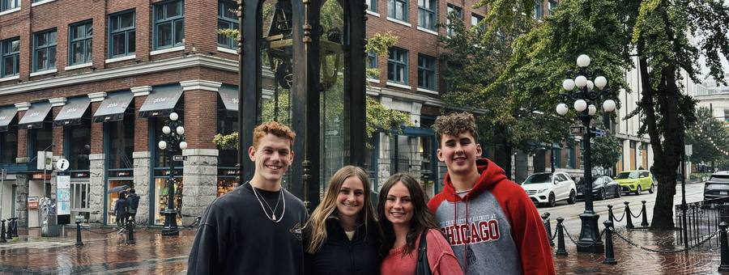

Vancouver

Brady · 22 Validated Spots

Best food city in the Pacific Northwest. Stanley Park, Granville Island, and some of the best sushi outside Japan. Go June through September.

[Bars & Food](https://maps.app.goo.gl/9n9uM7NG8Sa2aA8) [Things to Do](https://maps.app.goo.gl/4moCgAkEHz5uJbQ9A)

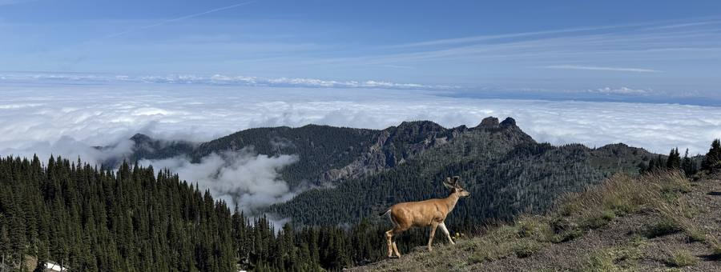

Seattle + Olympic National Park

Brady · 14 Spots in Database

Pike Place, Capitol Hill bars, and a day trip to Olympic that makes the whole trip. Best late summer when the rain takes a break.

[Google Maps →](https://maps.app.goo.gl/Fr7KdvoLsnXeBV1q8)

Phoenix + Golf

Brady · 7 Spots in Database

Golf trip capital. Shoulder season pricing in late spring or early fall saves serious money. Scottsdale nightlife is better than expected.

[Google Maps →](https://maps.app.goo.gl/PTJn6coPBcRDKbHw5)

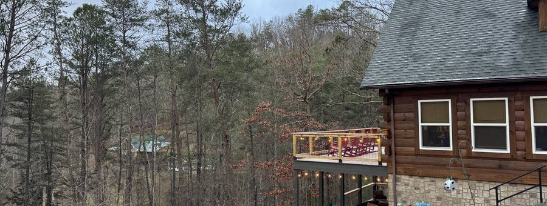

Smoky Mountains

Brady · 8 Spots in Database

Cabin on the quiet side, away from Gatlinburg crowds. Fall colors are the move. Solid brewery scene in the area.

Las Vegas

Both Lads

Best as 3–4 nights. The strip is the strip — but the off-strip food scene is where the real value is. Midweek shoulder rates at the big hotels drop significantly.

Charleston

Brady

Best food city in the South, and it’s not close. King Street for bars, Sullivan’s Island for the beach day. Two–three nights is the move.

One-Pager →

The Lads Travel Co.

© 2026

The Lads

# Two Guys. 25+ Countries. *Four Continents.*

[figure not shown]

Brady

Study Abroad: Sydney, Australia

M.S. Applied Statistics, Grand Valley State. Studied abroad in Sydney for six weeks. 25+ countries across four continents. Built the AI research system, the database, and every framework on this site. Former peer advisor at GVSU’s Padnos International Center. Starting at Ford Motor Company May 18th, 2026. Completed full onboarding through Outside Agents Travel Agency — and decided the industry was built to benefit agents, not travelers. So he built this instead.

Dawson

Study Abroad: Madrid, Spain

Data Analytics, Kalamazoo College. Studied abroad in Madrid. Completed the full Iceland Ring Road. Deep firsthand knowledge of Spain, Ireland, Iceland, Rome, and Paris. 35+ pubs in Ireland in one week. The other half of every “Both Lads” validation label on this site.

Study Abroad Mission

Brady spent a year as a peer advisor at GVSU’s Padnos International Center — helping students figure out where to go, what to expect, and how to make the most of it. That mission hasn’t changed. If you’re heading abroad to a city we know, the knowledge is free. Reach out.

The Build

Nine trip frameworks, a six-agent AI research system, a 650-spot validated database, and this website — built in 20 days while Brady finished his graduate degree. It started as a proof of concept and turned into something worth showing.

[figure not shown]

Ready to Start?

Fill this out. Brady follows up within 24 hours.

Name *

Email *

International or Domestic?

Destination

Travel Dates

Group Size

Budget Per Person

Trip Style

NightlifeCultureBeachAdventureFood & DrinkMix

Cities Already Visited

Savings Priority

How’d You Hear About Us?

Anything Else?

### Got it.

Brady will follow up within 24 hours.

Contact

dangelobraden43@gmail.com

The Lads Travel Co.

© 2026